# The Solar Neighborhood

The Solar Neighborhood can be roughly defined as all of the objects within 10 pc of the Sun.

- Objects within 10 pc of the Sun will have parallax values greater than 100 mas.

Create and run a Gaia query to find a high quality complete sample of all of the objects Gaia surveyed within the Solar Neighborhood.

- Your sample should only have high quality data (parallax SNR > 15)
- All of your objects should have bp-rp colors and radial velocity measurements.

You will want the columns: `source_id, bp_rp, parallax, parallax_over_error, pmra, pmdec, radial_velocity`

Don't print out the entire object table!

```python
import matplotlib.pyplot as plt
import matplotlib.image as mpimg

import numpy as np
import astropy.units as u

from astroquery.simbad import Simbad

from astropy.table import QTable
from astroquery.gaia import Gaia
```

```python
my_query = f"""
SELECT TOP 1500
source_id, bp_rp, parallax, parallax_over_error, pmra, pmdec, radial_velocity
FROM gaiadr3.gaia_source_lite
WHERE parallax > 100
AND parallax_over_error > 15
AND bp_rp IS NOT NULL
AND radial_velocity IS NOT NULL
"""
```

```python
my_job_query = Gaia.launch_job_async(my_query)
```

```
INFO: Query finished. [astroquery.utils.tap.core]
```

```python
print(my_query)
```

```
SELECT TOP 1500
source_id, bp_rp, parallax, parallax_over_error, pmra, pmdec, radial_velocity
FROM gaiadr3.gaia_source_lite
WHERE parallax > 100
AND parallax_over_error > 15
AND bp_rp IS NOT NULL
AND radial_velocity IS NOT NULL
```

```python
my_table = my_job_query.get_results()
```

```python
my_table.info()
```

```
<Table length=216>
        name         dtype    unit                              description
------------------- ------- -------- ------------------------------------------------------------------
          source_id   int64          Unique source identifier (unique within a particular Data Release)
              bp_rp float32      mag                                                     BP - RP colour
           parallax float64      mas                                                           Parallax
parallax_over_error float32                                      Parallax divided by its standard error
               pmra float64 mas / yr                         Proper motion in right ascension direction
              pmdec float64 mas / yr                             Proper motion in declination direction
    radial_velocity float32   km / s                                                    Radial velocity
```

## Make a plot of `pmra` vs `pmdec` for the objects in the Solar Neighborhood

- Adjust your values for the X and Y limits so the center of the plot is (0,0)
- Make the points easy to see
- Label the axes

```python
pmra = my_table['pmra']
pmdec = my_table['pmdec']

pmra_max = pmra.max()
print(f"This is the max RA: {pmra_max}")

pmdec_max = pmdec.max()
print(f"This is the max Dec: {pmdec_max}")
```

```
This is the max RA: 6765.995136250774
This is the max Dec: 10362.394206546573
```

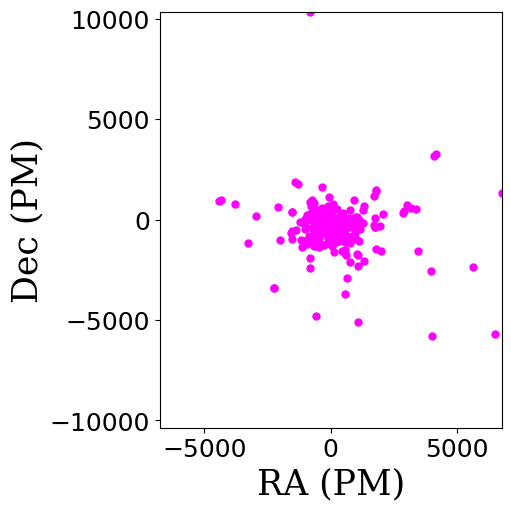

```python
fig, ax = plt.subplots(
    figsize = (5, 5),
    constrained_layout = True
)

ax.tick_params(axis='both', which='major', labelsize = 18)

ax.set_xlabel("RA (PM)",
              fontfamily = 'serif',
              fontsize = 25)

ax.set_ylabel("Dec (PM)",
              fontfamily = 'serif',
              fontsize = 25)

ax.set_xlim(-pmra_max, np.abs(pmra_max))
ax.set_ylim(-pmdec_max, np.abs(pmdec_max))

ax.plot(pmra, pmdec,
        color = "fuchsia",
        marker = ".",
        linestyle = "None",
        markersize = 10
       );
```

## Make a histogram of the values of the `radial velocity`.

- Use bin sizes of 10 km/s
- Label the axes

```
(array([  1.,   0.,   0.,   0.,   6.,  43., 152.,  12.,   1.,   1.]),
 array([-414.01544189, -348.10858154, -282.20172119, -216.29486084,
        -150.38800049,  -84.48114014,  -18.57427979,   47.33258057,
         113.23944092,  179.14630127,  245.0531311 ]),
```

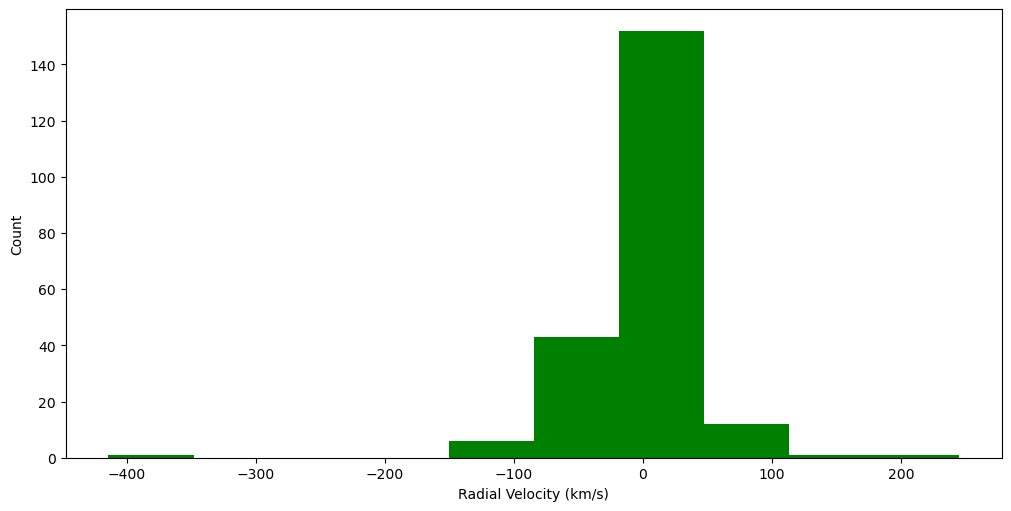

```python
fig, ax = plt.subplots(
    figsize = (10, 5),
    constrained_layout = True
)

ax.set_xlabel("Radial Velocity (km/s)")
ax.set_ylabel("Count")

ax.hist(my_table['radial_velocity'],
        bins = 10,
        histtype = 'stepfilled',
        facecolor = 'green')
```

## Calculate the total space velocity for the Solar Neighborhood objects

```python
my_table['pm_total'] = ((my_table['pmra'] ** 2) + (my_table['pmdec'] ** 2)) ** 0.5
```

```python
my_table['tangential_velocity'] = 4.74047 * (my_table['pm_total']/ my_table['parallax'])
```

```python
my_table['total_velocity'] = ((my_table['tangential_velocity'] ** 2) + (my_table['radial_velocity'] ** 2))
```

## Make a histogram of the values of the `total space velocity`.

- Use bin sizes of 10 km/s
- Label the axes

```
(array([206.,   7.,   0.,   0.,   1.,   0.,   1.,   0.,   0.,   1.]),
 array([2.08762243e+01, 1.73156644e+04, 3.46104525e+04, 5.19052407e+04,
        6.92000288e+04, 8.64948170e+04, 1.03789605e+05, 1.21084393e+05,
        1.38379181e+05, 1.55673970e+05, 1.72968758e+05]),
```

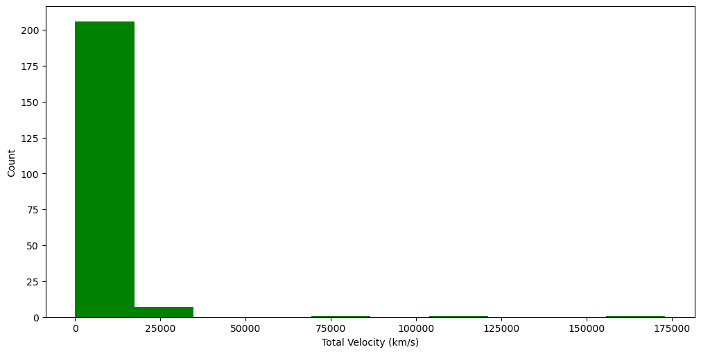

```python
fig, ax = plt.subplots(
    figsize = (10, 5),
    constrained_layout = True
)

ax.set_xlabel("Total Velocity (km/s)")
ax.set_ylabel("Count")

ax.hist(my_table['total_velocity'],
        bins = 10,
        histtype = 'stepfilled',
        facecolor = 'green')
```

## Speedy Object

You should notice that one of the objects has a very high total space velocity.

Print out the following sentence for the high velocity object.

`The object with the highest space velocity in the solar neighborhood is OBJECT_ID with a velocity of VELOCITY km/s and a parallax of PARALLAX mas. The color of the object is BP_RP which is within BP_RP - SOLAR_COLOR mags of the Sun's color.`

- The Sun has a `bp_rp` value of 0.82
- Use `f-string` formatting to make your output look nice.
- **All floats should be printed to one decimal place**.
- Your output should **NOT** be all be all on one line that needs to be scrolled through.
- Replace the CAP values with data. **DO NOT HARDCODE!!** - use variables.

```python
my_table.sort('velocity_total')
fastest = my_table[-1:]
fastest.info('stats')
```

```
<Table length=1>
        name            mean    std     min         max
------------------- ----------- --- ----------- -----------
          source_id 3.32018e+18   0 3.32018e+18 3.32018e+18
              bp_rp    0.830926   0    0.830926    0.830926
           parallax     123.199   0     123.199     123.199
parallax_over_error     7244.72   0     7244.72     7244.72
               pmra    -444.685   0    -444.685    -444.685
              pmdec     -925.14   0     -925.14     -925.14
    radial_velocity    -414.015   0    -414.015    -414.015
           Total_PM     1026.46   0     1026.46     1026.46
           pm_total     1026.46   0     1026.46     1026.46
tangential_velocity     39.4965   0     39.4965     39.4965
     velocity_total      172969   0      172969      172969
     total_velocity      172969   0      172969      172969
```

```python
sun_bprp = 0.82
object_id = float(fastest['source_id'])
velocity = float(fastest['velocity_total'])
parallax = float(fastest['parallax'])
bp_rp = float(fastest['bp_rp'])
color = float(bp_rp - sun_bprp)

print(f"""The object with the highest space velocity in the solar neighborhood is {object_id:.5e},
with a velocity of {velocity:.2e} km/s and a parallax of {parallax:.2f} mas. The color of the object is {bp_rp:.2f},
which is within {color:.3f} mags of the Sun's color.""")
```

```
The object with the highest space velocity in the solar neighborhood is 3.32018e+18,
with a velocity of 1.73e+05 km/s and a parallax of 123.20 mas. The color of the object is 0.83,
which is within 0.011 mags of the Sun's color.
```

# Pretty Pictures - Pick an Object

## Pick an interesting-to-you (non-Solar System) object.

### [Here is a good place for ideas](https://en.wikipedia.org/wiki/Lists_of_astronomical_objects)

### The [Arp catalog](https://en.wikipedia.org/wiki/Atlas_of_Peculiar_Galaxies) is a particularly good list for the more decerning tastes.

### Don't pick a field with just one bright star in it (i.e Sirius).

# [The STScI Digitized Sky Survey](https://archive.stsci.edu/cgi-bin/dss_form)

- Download a GIF images of your object
- Adjust the width and height so that you can see the entire object with a little context
- Pick the Survey that looks best to you
- Upload the GIF of your object to this directory
- Plot up the image

```python
M31_image = mpimg.imread("./dss_search.gif")
```

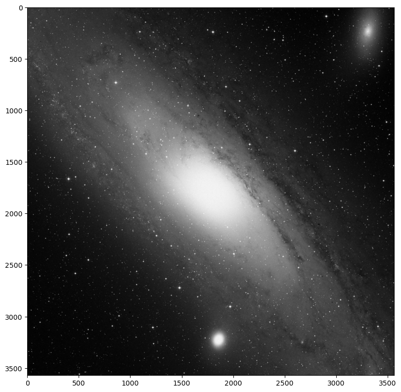

```python
fig, ax = plt.subplots(
    figsize = (8, 8),
    constrained_layout = True
)

ax.imshow(M31_image, cmap = plt.cm.gray); #note, I did the max allowed on the site
```

### Due Wed Feb 18 - 1 pm

- `File -> Download as -> HTML (.html)`
- `upload your .html file to the class Canvas page`